# Predicting Customer Churn in Telecom Industry: A Machine Learning Approach

Group 7: Tzu-Yu Ko, Yeonji Kim, Jake Liang, Srihari Katari Srinivasula, Sandy Yen

2023-04-05 - intermediate deliverable

# 1 Business Case and Analysis Overview

- Customer churn is a major challenge for telecom companies, impacting revenue and profitability. To address this challenge, telecom companies need to predict and prevent churn using machine learning models and churn analytics.
- Our goal is to explore how telecom companies can reduce churn by building accurate machine learning models and using churn analytics to identify customers at risk of churning, and take proactive measures to retain them.

# 2 Datasets Exploration

- We will leverage a dataset (“Telco Customer Churn”) from Kaggle containing various attributes associated with each customer, including churn indicator, demographic information, account information, and services information. These variables serve as inputs for building a machine learning model to predict churn and develop retention strategies.

## 2.1 Content

# 3 Link to GitHub repository

- https://github.com/sandychy/T0628GroupProject

# 4 Preliminary Exploration And Data Cleaning

## 4.1 Data Exploration

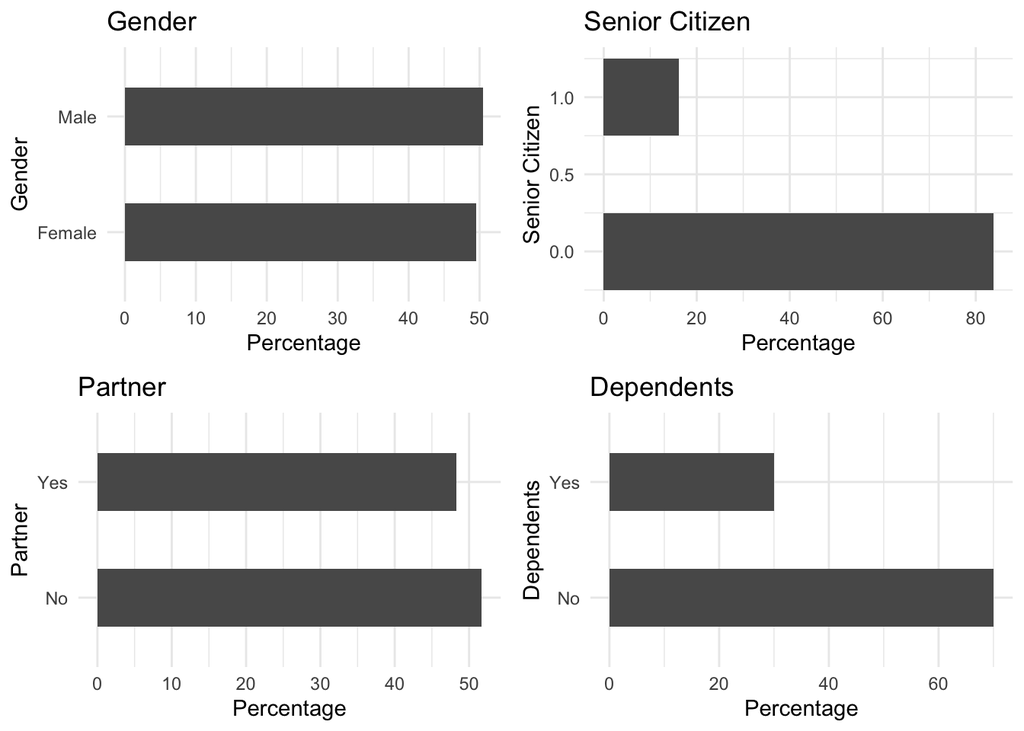

```r
library(ggplot2)
library(dplyr)
library(gridExtra)
data <- read.csv("Telco Customer Churn.csv")

p1 <- ggplot(data, aes(x=gender)) + ggtitle("Gender") + xlab("Gender") +
   geom_bar(aes(y = 100*(..count..)/sum(..count..)), width = 0.5) + ylab("Percentage") + coord_flip() + theme_minimal()
p2 <- ggplot(data, aes(x=SeniorCitizen)) + ggtitle("Senior Citizen") + xlab("Senior Citizen") +
   geom_bar(aes(y = 100*(..count..)/sum(..count..)), width = 0.5) + ylab("Percentage") + coord_flip() + theme_minimal()
p3 <- ggplot(data, aes(x=Partner)) + ggtitle("Partner") + xlab("Partner") +
   geom_bar(aes(y = 100*(..count..)/sum(..count..)), width = 0.5) + ylab("Percentage") + coord_flip() + theme_minimal()
p4 <- ggplot(data, aes(x=Dependents)) + ggtitle("Dependents") + xlab("Dependents") +
   geom_bar(aes(y = 100*(..count..)/sum(..count..)), width = 0.5) + ylab("Percentage") + coord_flip() + theme_minimal()
grid.arrange(p1, p2, p3, p4, ncol=2)
```

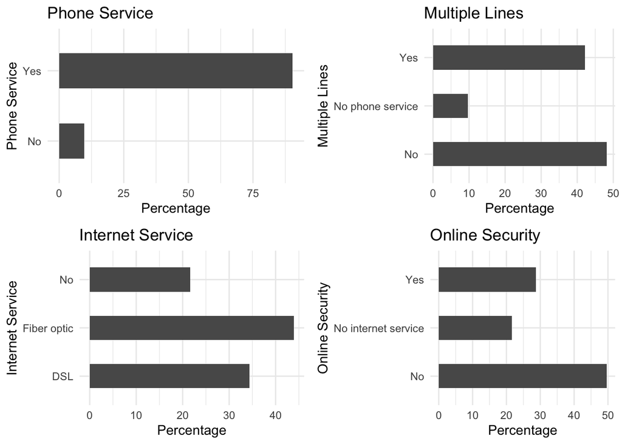

```r
p5 <- ggplot(data, aes(x=PhoneService)) + ggtitle("Phone Service") + xlab("Phone Service") +
  geom_bar(aes(y = 100*(..count..)/sum(..count..)), width = 0.5) + ylab("Percentage") + coord_flip() + theme_minimal()
p6 <- ggplot(data, aes(x=MultipleLines)) + ggtitle("Multiple Lines") + xlab("Multiple Lines") +
  geom_bar(aes(y = 100*(..count..)/sum(..count..)), width = 0.5) + ylab("Percentage") + coord_flip() + theme_minimal()
p7 <- ggplot(data, aes(x=InternetService)) + ggtitle("Internet Service") + xlab("Internet Service") +
  geom_bar(aes(y = 100*(..count..)/sum(..count..)), width = 0.5) + ylab("Percentage") + coord_flip() + theme_minimal()
p8 <- ggplot(data, aes(x=OnlineSecurity)) + ggtitle("Online Security") + xlab("Online Security") +
  geom_bar(aes(y = 100*(..count..)/sum(..count..)), width = 0.5) + ylab("Percentage") + coord_flip() + theme_minimal()
grid.arrange(p5, p6, p7, p8, ncol=2)
```

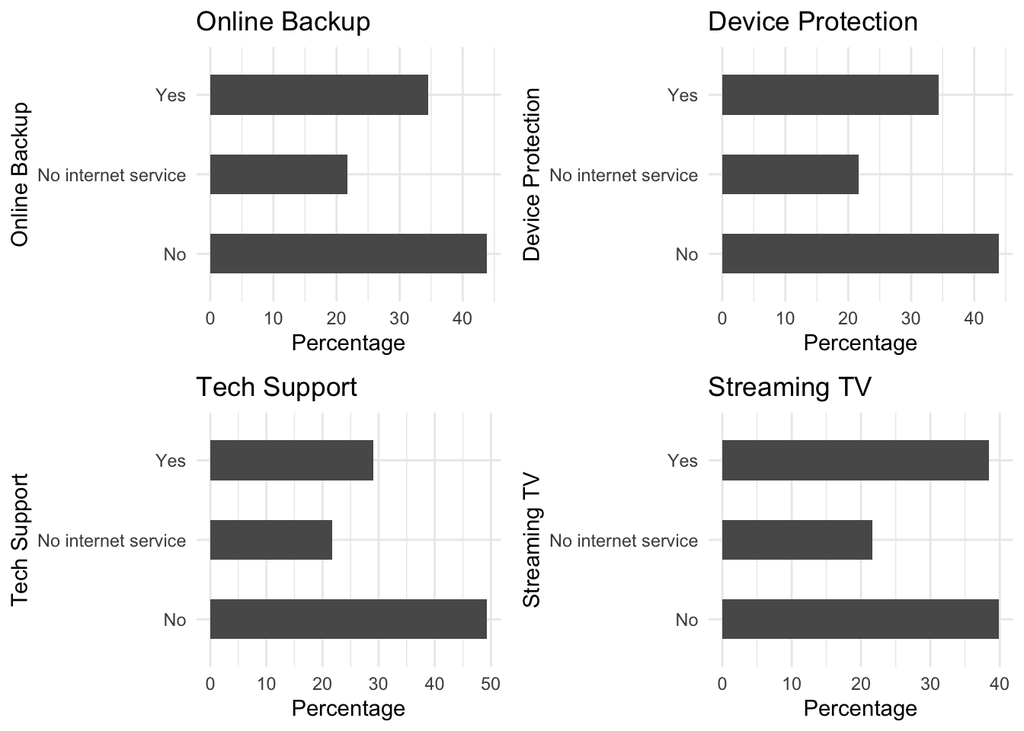

```r
p9 <- ggplot(data, aes(x=OnlineBackup)) + ggtitle("Online Backup") + xlab("Online Backup") +
  geom_bar(aes(y = 100*(..count..)/sum(..count..)), width = 0.5) + ylab("Percentage") + coord_flip() + theme_minimal()
p10 <- ggplot(data, aes(x=DeviceProtection)) + ggtitle("Device Protection") + xlab("Device Protection") +
  geom_bar(aes(y = 100*(..count..)/sum(..count..)), width = 0.5) + ylab("Percentage") + coord_flip() + theme_minimal()
p11 <- ggplot(data, aes(x=TechSupport)) + ggtitle("Tech Support") + xlab("Tech Support") +
  geom_bar(aes(y = 100*(..count..)/sum(..count..)), width = 0.5) + ylab("Percentage") + coord_flip() + theme_minimal()
p12 <- ggplot(data, aes(x=StreamingTV)) + ggtitle("Streaming TV") + xlab("Streaming TV") +
  geom_bar(aes(y = 100*(..count..)/sum(..count..)), width = 0.5) + ylab("Percentage") + coord_flip() + theme_minimal()
grid.arrange(p9, p10, p11, p12, ncol=2)
```

```r
# Customer churn rate
churn_breakdown <- data %>%
   group_by(Churn) %>%
   count(Churn) %>%
   mutate(perc = n/nrow(data) * 100) %>%
   rename(customers = n)
 churn_breakdown
```

```
## # A tibble: 2 × 3
## # Groups:   Churn [2]
##   Churn customers  perc
##   <chr>     <int> <dbl>
## 1 No         5174  73.5
## 2 Yes        1869  26.5
```

```r
round(prop.table(table(data$gender, data$Churn), 1), 3)
```

```
##
##             No   Yes
##   Female 0.731 0.269
##   Male   0.738 0.262
```

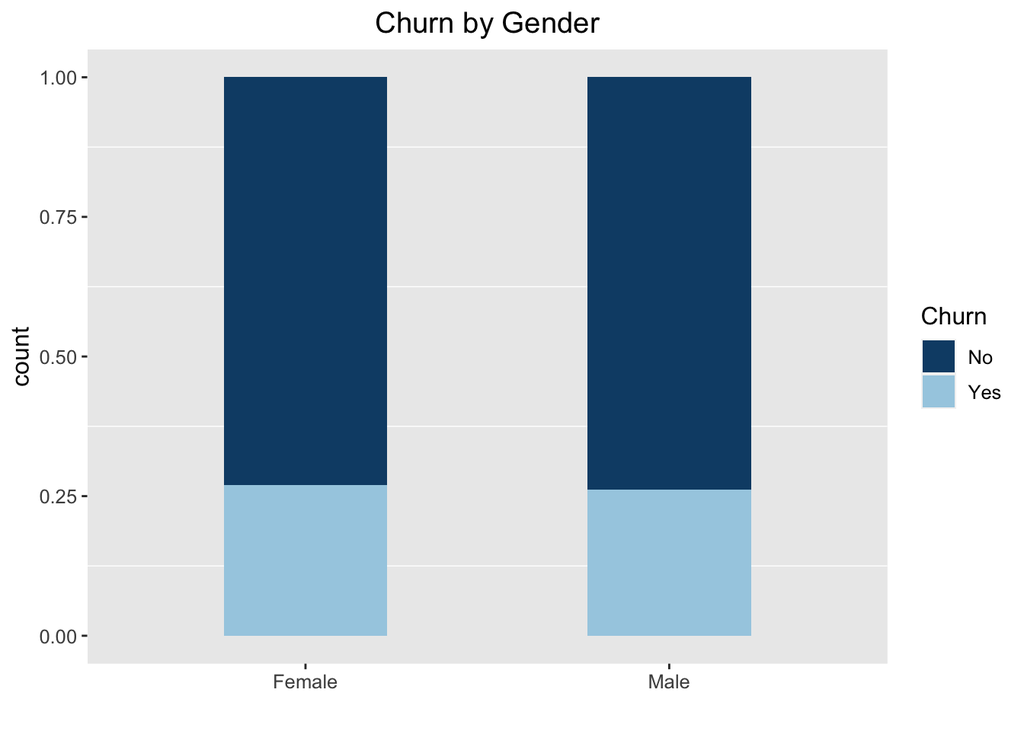

```r
# Churn rate by gender
ggplot(data = data, aes(x=gender, fill =  Churn)) + geom_bar(position = "fill", width=0.45) +
     scale_fill_manual(values = c("#0F4C75", "#a6cee3")) +
     theme(
     plot.background = element_blank(),
     panel.grid.major = element_blank(),
     panel.border = element_blank(),
     plot.title = element_text(hjust = 0.5),
     text=element_text(size=12)) +
     labs(x = " ", title = "Churn by Gender")
```

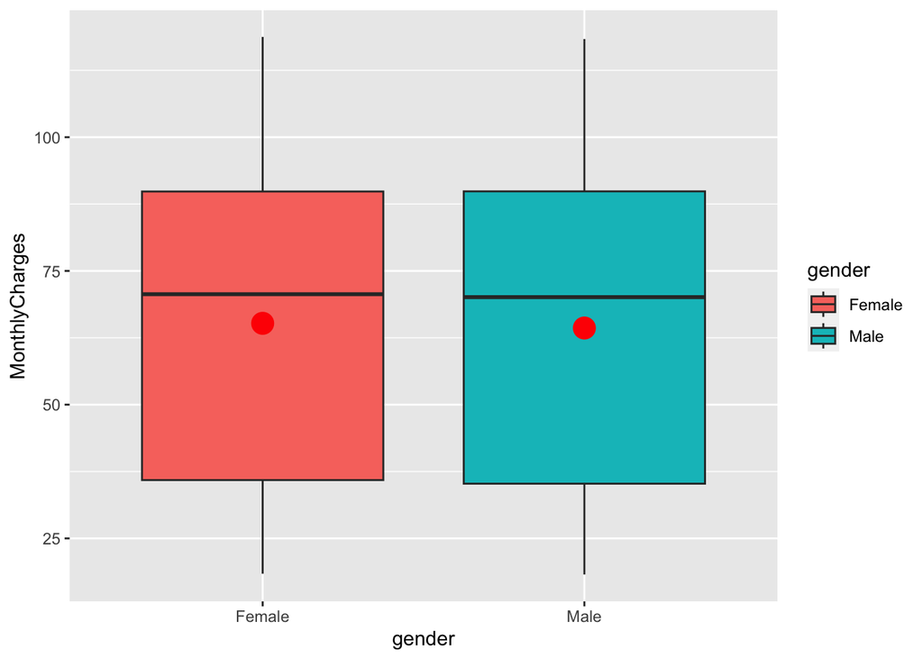

```r
ggplot(data = data, aes(x = gender, y = MonthlyCharges, fill = gender))+geom_boxplot() + stat_summary(fun=mean, geom="point", shape=20, size=8, color="red", fill="red")
```

The existing churn rate of 26.54% indicates that there is a need for action to reduce customer churn. A high churn rate indicates that a significant percentage of customers are leaving the company, which can result in several negative impacts, such as increased costs of acquiring new customers and reduced revenue due to customers leaving for competitors. Therefore, it is essential for telecom companies to take proactive measures to reduce customer churn and retain their existing customer base.

## 4.2 Get Data

```r
data <- read.csv("Telco Customer Churn.csv")
#str(data)
#summary(data)
#View(data)
```

## 4.3 Clean Data

We checked if there is any data with NAs.

```r
colSums(is.na(data))
```

```
##       customerID           gender    SeniorCitizen          Partner
##                0                0                0                0
##       Dependents           tenure     PhoneService    MultipleLines
##                0                0                0                0
##  InternetService   OnlineSecurity     OnlineBackup DeviceProtection
##                0                0                0                0
##      TechSupport      StreamingTV  StreamingMovies         Contract
##                0                0                0                0
## PaperlessBilling    PaymentMethod   MonthlyCharges     TotalCharges
##                0                0                0               11
##            Churn
##                0
```

It appeared that there are NAs in the ‘TotalCharges’ column. To handle NAs, we calculated the mean of the column and replaced NAs with the mean.

```r
mean_TotalCharges = mean(data$TotalCharges, na.rm = TRUE) # Calculate the mean
data$TotalCharges = ifelse(is.na(data$TotalCharges), mean_TotalCharges, data$TotalCharges) # If NA, replace it with the mean.
colSums(is.na(data)) # Check for NAs
```

```
##       customerID           gender    SeniorCitizen          Partner
##                0                0                0                0
##       Dependents           tenure     PhoneService    MultipleLines
##                0                0                0                0
##  InternetService   OnlineSecurity     OnlineBackup DeviceProtection
##                0                0                0                0
##      TechSupport      StreamingTV  StreamingMovies         Contract
##                0                0                0                0
## PaperlessBilling    PaymentMethod   MonthlyCharges     TotalCharges
##                0                0                0                0
##            Churn
##                0
```

```r
str(data)
```

```
## 'data.frame':    7043 obs. of  21 variables:
##  $ customerID      : chr  "7590-VHVEG" "5575-GNVDE" "3668-QPYBK" "7795-CFOCW" ...
##  $ gender          : chr  "Female" "Male" "Male" "Male" ...
##  $ SeniorCitizen   : int  0 0 0 0 0 0 0 0 0 0 ...
##  $ Partner         : chr  "Yes" "No" "No" "No" ...
##  $ Dependents      : chr  "No" "No" "No" "No" ...
##  $ tenure          : int  1 34 2 45 2 8 22 10 28 62 ...
##  $ PhoneService    : chr  "No" "Yes" "Yes" "No" ...
##  $ MultipleLines   : chr  "No phone service" "No" "No" "No phone service" ...
##  $ InternetService : chr  "DSL" "DSL" "DSL" "DSL" ...
##  $ OnlineSecurity  : chr  "No" "Yes" "Yes" "Yes" ...
##  $ OnlineBackup    : chr  "Yes" "No" "Yes" "No" ...
##  $ DeviceProtection: chr  "No" "Yes" "No" "Yes" ...
##  $ TechSupport     : chr  "No" "No" "No" "Yes" ...
##  $ StreamingTV     : chr  "No" "No" "No" "No" ...
##  $ StreamingMovies : chr  "No" "No" "No" "No" ...
##  $ Contract        : chr  "Month-to-month" "One year" "Month-to-month" "One year" ...
##  $ PaperlessBilling: chr  "Yes" "No" "Yes" "No" ...
##  $ PaymentMethod   : chr  "Electronic check" "Mailed check" "Mailed check" "Bank transfer (automatic)" ...
##  $ MonthlyCharges  : num  29.9 57 53.9 42.3 70.7 ...
##  $ TotalCharges    : num  29.9 1889.5 108.2 1840.8 151.7 ...
##  $ Churn           : chr  "No" "No" "Yes" "No" ...
```

```r
summary(data)
```

```
##   customerID           gender          SeniorCitizen      Partner
##  Length:7043        Length:7043        Min.   :0.0000   Length:7043
##  Class :character   Class :character   1st Qu.:0.0000   Class :character
##  Mode  :character   Mode  :character   Median :0.0000   Mode  :character
##                                        Mean   :0.1621
##                                        3rd Qu.:0.0000
##                                        Max.   :1.0000
##   Dependents            tenure      PhoneService       MultipleLines
##  Length:7043        Min.   : 0.00   Length:7043        Length:7043
##  Class :character   1st Qu.: 9.00   Class :character   Class :character
##  Mode  :character   Median :29.00   Mode  :character   Mode  :character
##                     Mean   :32.37
##                     3rd Qu.:55.00
##                     Max.   :72.00
##  InternetService    OnlineSecurity     OnlineBackup       DeviceProtection
##  Length:7043        Length:7043        Length:7043        Length:7043
##  Class :character   Class :character   Class :character   Class :character
##  Mode  :character   Mode  :character   Mode  :character   Mode  :character
##
##
##
##  TechSupport        StreamingTV        StreamingMovies      Contract
##  Length:7043        Length:7043        Length:7043        Length:7043
##  Class :character   Class :character   Class :character   Class :character
##  Mode  :character   Mode  :character   Mode  :character   Mode  :character
##
##
##
##  PaperlessBilling   PaymentMethod      MonthlyCharges    TotalCharges
##  Length:7043        Length:7043        Min.   : 18.25   Min.   :  18.8
##  Class :character   Class :character   1st Qu.: 35.50   1st Qu.: 402.2
##  Mode  :character   Mode  :character   Median : 70.35   Median :1400.5
##                                        Mean   : 64.76   Mean   :2283.3
##                                        3rd Qu.: 89.85   3rd Qu.:3786.6
##                                        Max.   :118.75   Max.   :8684.8
##     Churn
##  Length:7043
##  Class :character
##  Mode  :character
##
##
##
```

Then, we factorized and normalized the data and overwrote them to the same columns.

```r
data$gender <- as.factor(data$gender)
data$Partner <- as.factor(data$Partner)
data$Dependents <- as.factor(data$Dependents)
data$PhoneService <- as.factor(data$PhoneService)
data$MultipleLines <- as.factor(data$MultipleLines)
data$InternetService <- as.factor(data$InternetService)
data$OnlineSecurity <- as.factor(data$OnlineSecurity)
data$OnlineBackup <- as.factor(data$OnlineBackup)
data$DeviceProtection <- as.factor(data$DeviceProtection)
data$TechSupport <- as.factor(data$TechSupport)
data$StreamingTV <- as.factor(data$StreamingTV)
data$StreamingMovies <- as.factor(data$StreamingMovies)
data$Contract <- as.factor(data$Contract)
data$PaperlessBilling <- as.factor(data$PaperlessBilling)
data$PaymentMethod <- as.factor(data$PaymentMethod)
data$Churn <- ifelse(data$Churn == "Yes", 1, 0)
data$customerID <- NULL
# Data for autotune train()
data_str <- data.frame(data)
str(data_str)
```

```
## 'data.frame':    7043 obs. of  20 variables:
##  $ gender          : Factor w/ 2 levels "Female","Male": 1 2 2 2 1 1 2 1 1 2 ...
##  $ SeniorCitizen   : int  0 0 0 0 0 0 0 0 0 0 ...
##  $ Partner         : Factor w/ 2 levels "No","Yes": 2 1 1 1 1 1 1 1 2 1 ...
##  $ Dependents      : Factor w/ 2 levels "No","Yes": 1 1 1 1 1 1 2 1 1 2 ...
##  $ tenure          : int  1 34 2 45 2 8 22 10 28 62 ...
##  $ PhoneService    : Factor w/ 2 levels "No","Yes": 1 2 2 1 2 2 2 1 2 2 ...
##  $ MultipleLines   : Factor w/ 3 levels "No","No phone service",..: 2 1 1 2 1 3 3 2 3 1 ...
##  $ InternetService : Factor w/ 3 levels "DSL","Fiber optic",..: 1 1 1 1 2 2 2 1 2 1 ...
##  $ OnlineSecurity  : Factor w/ 3 levels "No","No internet service",..: 1 3 3 3 1 1 1 3 1 3 ...
##  $ OnlineBackup    : Factor w/ 3 levels "No","No internet service",..: 3 1 3 1 1 1 3 1 1 3 ...
##  $ DeviceProtection: Factor w/ 3 levels "No","No internet service",..: 1 3 1 3 1 3 1 1 3 1 ...
##  $ TechSupport     : Factor w/ 3 levels "No","No internet service",..: 1 1 1 3 1 1 1 1 3 1 ...
##  $ StreamingTV     : Factor w/ 3 levels "No","No internet service",..: 1 1 1 1 1 3 3 1 3 1 ...
##  $ StreamingMovies : Factor w/ 3 levels "No","No internet service",..: 1 1 1 1 1 3 1 1 3 1 ...
##  $ Contract        : Factor w/ 3 levels "Month-to-month",..: 1 2 1 2 1 1 1 1 1 2 ...
##  $ PaperlessBilling: Factor w/ 2 levels "No","Yes": 2 1 2 1 2 2 2 1 2 1 ...
##  $ PaymentMethod   : Factor w/ 4 levels "Bank transfer (automatic)",..: 3 4 4 1 3 3 2 4 3 1 ...
##  $ MonthlyCharges  : num  29.9 57 53.9 42.3 70.7 ...
##  $ TotalCharges    : num  29.9 1889.5 108.2 1840.8 151.7 ...
##  $ Churn           : num  0 0 1 0 1 1 0 0 1 0 ...
```

```r
# Normalize Data
normalize <- function(x){ # new function
  (x - min(x))/(max(x)-min(x))
}
data$tenure <- normalize(data$tenure)
data$MonthlyCharges <- normalize(data$MonthlyCharges)
data$TotalCharges <- normalize(data$TotalCharges)
str(data)
```

```
## 'data.frame':    7043 obs. of  20 variables:
##  $ gender          : Factor w/ 2 levels "Female","Male": 1 2 2 2 1 1 2 1 1 2 ...
##  $ SeniorCitizen   : int  0 0 0 0 0 0 0 0 0 0 ...
##  $ Partner         : Factor w/ 2 levels "No","Yes": 2 1 1 1 1 1 1 1 2 1 ...
##  $ Dependents      : Factor w/ 2 levels "No","Yes": 1 1 1 1 1 1 2 1 1 2 ...
##  $ tenure          : num  0.0139 0.4722 0.0278 0.625 0.0278 ...
##  $ PhoneService    : Factor w/ 2 levels "No","Yes": 1 2 2 1 2 2 2 1 2 2 ...
##  $ MultipleLines   : Factor w/ 3 levels "No","No phone service",..: 2 1 1 2 1 3 3 2 3 1 ...
##  $ InternetService : Factor w/ 3 levels "DSL","Fiber optic",..: 1 1 1 1 2 2 2 1 2 1 ...
##  $ OnlineSecurity  : Factor w/ 3 levels "No","No internet service",..: 1 3 3 3 1 1 1 3 1 3 ...
##  $ OnlineBackup    : Factor w/ 3 levels "No","No internet service",..: 3 1 3 1 1 1 3 1 1 3 ...
##  $ DeviceProtection: Factor w/ 3 levels "No","No internet service",..: 1 3 1 3 1 3 1 1 3 1 ...
##  $ TechSupport     : Factor w/ 3 levels "No","No internet service",..: 1 1 1 3 1 1 1 1 3 1 ...
##  $ StreamingTV     : Factor w/ 3 levels "No","No internet service",..: 1 1 1 1 1 3 3 1 3 1 ...
##  $ StreamingMovies : Factor w/ 3 levels "No","No internet service",..: 1 1 1 1 1 3 1 1 3 1 ...
##  $ Contract        : Factor w/ 3 levels "Month-to-month",..: 1 2 1 2 1 1 1 1 1 2 ...
##  $ PaperlessBilling: Factor w/ 2 levels "No","Yes": 2 1 2 1 2 2 2 1 2 1 ...
##  $ PaymentMethod   : Factor w/ 4 levels "Bank transfer (automatic)",..: 3 4 4 1 3 3 2 4 3 1 ...
##  $ MonthlyCharges  : num  0.115 0.385 0.354 0.239 0.522 ...
##  $ TotalCharges    : num  0.00128 0.21587 0.01031 0.21024 0.01533 ...
##  $ Churn           : num  0 0 1 0 1 1 0 0 1 0 ...
```

```r
summary(data)
```

```
##     gender     SeniorCitizen    Partner    Dependents     tenure
##  Female:3488   Min.   :0.0000   No :3641   No :4933   Min.   :0.0000
##  Male  :3555   1st Qu.:0.0000   Yes:3402   Yes:2110   1st Qu.:0.1250
##                Median :0.0000                         Median :0.4028
##                Mean   :0.1621                         Mean   :0.4496
##                3rd Qu.:0.0000                         3rd Qu.:0.7639
##                Max.   :1.0000                         Max.   :1.0000
##  PhoneService          MultipleLines     InternetService
##  No : 682     No              :3390   DSL        :2421
##  Yes:6361     No phone service: 682   Fiber optic:3096
##               Yes             :2971   No         :1526
##
##
##
##              OnlineSecurity              OnlineBackup
##  No                 :3498   No                 :3088
##  No internet service:1526   No internet service:1526
##  Yes                :2019   Yes                :2429
##
##
##
##             DeviceProtection              TechSupport
##  No                 :3095    No                 :3473
##  No internet service:1526    No internet service:1526
##  Yes                :2422    Yes                :2044
##
##
##
##               StreamingTV              StreamingMovies           Contract
##  No                 :2810   No                 :2785   Month-to-month:3875
##  No internet service:1526   No internet service:1526   One year      :1473
##  Yes                :2707   Yes                :2732   Two year      :1695
##
##
##
##  PaperlessBilling                   PaymentMethod  MonthlyCharges
##  No :2872         Bank transfer (automatic):1544   Min.   :0.0000
##  Yes:4171         Credit card (automatic)  :1522   1st Qu.:0.1716
##                   Electronic check         :2365   Median :0.5184
##                   Mailed check             :1612   Mean   :0.4628
##                                                    3rd Qu.:0.7124
##                                                    Max.   :1.0000
##   TotalCharges         Churn
##  Min.   :0.00000   Min.   :0.0000
##  1st Qu.:0.04424   1st Qu.:0.0000
##  Median :0.15945   Median :0.0000
##  Mean   :0.26131   Mean   :0.2654
##  3rd Qu.:0.43478   3rd Qu.:1.0000
##  Max.   :1.00000   Max.   :1.0000
```

### 4.3.1 Getting Data Ready

```r
# Using model.matrix to convert all the factors to dummy variables
# We are converting all of the factors into dummy variables as the input into knn has to be numeric
datamm <- as.data.frame(model.matrix(~.-1, data)) # everything becomes 0 or 1 if it is a factor
#str(datamm)
# Randomize the rows in the data (shuffling the rows)
set.seed(12345)
datamm_random <- datamm[sample(nrow(datamm)),]
#Normalize the data
normalize <- function(x) {
  return ((x - min(x)) / (max(x) - min(x)))
}
# we are going to normalize everything
datamm_norm <- as.data.frame(lapply(datamm_random, normalize))
#View(datamm_norm)
```

### 4.3.2 Getting Train and Test Samples from datamm

```r
# consider 25% of the data as train
set.seed(12345)
data_test_set <- sample(1:nrow(datamm_norm), nrow(datamm_norm) * 0.25)
# Depending on R-version and computer, different rows may be selected.
# If that happens, results are different.
# Create a train set and test set
data_train <- datamm_norm[-data_test_set, -match("Churn", names(datamm_norm))] # remove y label
data_test <- datamm_norm[data_test_set, -match("Churn", names(datamm_norm))]
#Now the response (aka Labels) - only the Churn column
data_train_labels <- datamm_norm[-data_test_set, "Churn"]
data_test_labels <- datamm_norm[data_test_set, "Churn"]
# data for train()
set.seed(12345)
data_t_test_set <- sample(1:nrow(data_str), 0.25*nrow(data_str))
data_t_test <- data[data_t_test_set, ]
data_t_train <- data[-data_t_test_set, ]
str(data_t_train)
```

```
## 'data.frame':    5283 obs. of  20 variables:
##  $ gender          : Factor w/ 2 levels "Female","Male": 1 2 2 2 1 1 2 1 1 2 ...
##  $ SeniorCitizen   : int  0 0 0 0 0 0 0 0 0 0 ...
##  $ Partner         : Factor w/ 2 levels "No","Yes": 2 1 1 1 1 1 1 1 2 1 ...
##  $ Dependents      : Factor w/ 2 levels "No","Yes": 1 1 1 1 1 1 2 1 1 2 ...
##  $ tenure          : num  0.0139 0.4722 0.0278 0.625 0.0278 ...
##  $ PhoneService    : Factor w/ 2 levels "No","Yes": 1 2 2 1 2 2 2 1 2 2 ...
##  $ MultipleLines   : Factor w/ 3 levels "No","No phone service",..: 2 1 1 2 1 3 3 2 3 1 ...
##  $ InternetService : Factor w/ 3 levels "DSL","Fiber optic",..: 1 1 1 1 2 2 2 1 2 1 ...
##  $ OnlineSecurity  : Factor w/ 3 levels "No","No internet service",..: 1 3 3 3 1 1 1 3 1 3 ...
##  $ OnlineBackup    : Factor w/ 3 levels "No","No internet service",..: 3 1 3 1 1 1 3 1 1 3 ...
##  $ DeviceProtection: Factor w/ 3 levels "No","No internet service",..: 1 3 1 3 1 3 1 1 3 1 ...
##  $ TechSupport     : Factor w/ 3 levels "No","No internet service",..: 1 1 1 3 1 1 1 1 3 1 ...
##  $ StreamingTV     : Factor w/ 3 levels "No","No internet service",..: 1 1 1 1 1 3 3 1 3 1 ...
##  $ StreamingMovies : Factor w/ 3 levels "No","No internet service",..: 1 1 1 1 1 3 1 1 3 1 ...
##  $ Contract        : Factor w/ 3 levels "Month-to-month",..: 1 2 1 2 1 1 1 1 1 2 ...
##  $ PaperlessBilling: Factor w/ 2 levels "No","Yes": 2 1 2 1 2 2 2 1 2 1 ...
##  $ PaymentMethod   : Factor w/ 4 levels "Bank transfer (automatic)",..: 3 4 4 1 3 3 2 4 3 1 ...
##  $ MonthlyCharges  : num  0.115 0.385 0.354 0.239 0.522 ...
##  $ TotalCharges    : num  0.00128 0.21587 0.01031 0.21024 0.01533 ...
##  $ Churn           : num  0 0 1 0 1 1 0 0 1 0 ...
```

Before training, we divided the dataset into test data (25%) and train data (75%).

# 5 Analysis with Simple Models

## 5.1 Logistic Regression

### 5.1.1 Train Model

```r
lr_base_model <- glm(data_train_labels ~ ., data = data_train, family = "binomial")
summary(lr_base_model)
```

```
##
## Call:
## glm(formula = data_train_labels ~ ., family = "binomial", data = data_train)
##
## Deviance Residuals:
##     Min       1Q   Median       3Q      Max
## -1.9076  -0.6637  -0.2664   0.6733   3.4028
##
## Coefficients: (8 not defined because of singularities)
##                                      Estimate Std. Error z value Pr(>|z|)
## (Intercept)                          -0.05336    0.32702  -0.163 0.870388
## genderFemale                          0.01791    0.07586   0.236 0.813309
## genderMale                                 NA         NA      NA       NA
## SeniorCitizen                         0.23399    0.09998   2.340 0.019261 *
## PartnerYes                           -0.04007    0.09169  -0.437 0.662057
## DependentsYes                        -0.09795    0.10581  -0.926 0.354560
## tenure                               -4.27263    0.51685  -8.267  < 2e-16 ***
## PhoneServiceYes                      -0.61254    0.76057  -0.805 0.420610
## MultipleLinesNo.phone.service              NA         NA      NA       NA
## MultipleLinesYes                      0.32383    0.20791   1.558 0.119331
## InternetServiceFiber.optic            0.61239    0.93943   0.652 0.514481
## InternetServiceNo                    -0.68315    0.94901  -0.720 0.471617
## OnlineSecurityNo.internet.service          NA         NA      NA       NA
## OnlineSecurityYes                    -0.51176    0.20954  -2.442 0.014592 *
## OnlineBackupNo.internet.service            NA         NA      NA       NA
## OnlineBackupYes                      -0.18187    0.20655  -0.881 0.378588
## DeviceProtectionNo.internet.service        NA         NA      NA       NA
## DeviceProtectionYes                  -0.04610    0.20747  -0.222 0.824140
## TechSupportNo.internet.service             NA         NA      NA       NA
## TechSupportYes                       -0.41025    0.21253  -1.930 0.053569 .
## StreamingTVNo.internet.service             NA         NA      NA       NA
## StreamingTVYes                        0.19704    0.38441   0.513 0.608249
## StreamingMoviesNo.internet.service         NA         NA      NA       NA
## StreamingMoviesYes                    0.22841    0.38245   0.597 0.550352
## ContractOne.year                     -0.75257    0.12582  -5.981 2.22e-09 ***
## ContractTwo.year                     -1.53228    0.20979  -7.304 2.79e-13 ***
## PaperlessBillingYes                   0.43572    0.08722   4.996 5.87e-07 ***
## PaymentMethodCredit.card..automatic. -0.08133    0.13356  -0.609 0.542578
## PaymentMethodElectronic.check         0.38093    0.11104   3.431 0.000602 ***
## PaymentMethodMailed.check            -0.01501    0.13600  -0.110 0.912138
## MonthlyCharges                        0.21359    3.75592   0.057 0.954651
## TotalCharges                          2.80679    0.70653   3.973 7.11e-05 ***
## ---
## Signif. codes:  0 '***' 0.001 '**' 0.01 '*' 0.05 '.' 0.1 ' ' 1
##
## (Dispersion parameter for binomial family taken to be 1)
##
##     Null deviance: 6078.7  on 5282  degrees of freedom
## Residual deviance: 4268.9  on 5259  degrees of freedom
## AIC: 4316.9
##
## Number of Fisher Scoring iterations: 6
```

We could find that the following columns and factors had significant effects:

- tenure column
- ‘One year’ and ‘Two year’ factors for the Contract column
- ‘Yes’ factor for the PaperlessBilling column

### 5.1.2 Predict

To test how our model will work with new data, we used the predict function with our test dataset.

```r
lr_pred <- predict(lr_base_model, data_test, type = "response")
summary(lr_pred)
```

```
##      Min.   1st Qu.    Median      Mean   3rd Qu.      Max.
## 0.0009953 0.0439116 0.1994546 0.2758891 0.4897506 0.8647800
```

Then, we translated the predictions into binary, so that we can see it in “Yes” and “No”.

```r
lr_binary_pred <- ifelse(lr_pred >= 0.5, 1, 0)
table(lr_binary_pred)
```

```
## lr_binary_pred
##    0    1
## 1335  425
```

```r
#levels(data_test$Churn)
#levels(churn_binary_pred)
```

### 5.1.3 Evaluate Model

With the confusionMatrix, we evaluated our prediction from the logistic regression model.

```r
library(caret)
library(gmodels)
confusionMatrix(as.factor(lr_binary_pred), as.factor(data_test_labels), positive = "1")
```

```
## Confusion Matrix and Statistics
##
##           Reference
## Prediction    0    1
##          0 1110  225
##          1  166  259
##
##                Accuracy : 0.7778
##                  95% CI : (0.7577, 0.7971)
##     No Information Rate : 0.725
##     P-Value [Acc > NIR] : 2.292e-07
##
##                   Kappa : 0.421
##
##  Mcnemar's Test P-Value : 0.003355
##
##             Sensitivity : 0.5351
##             Specificity : 0.8699
##          Pos Pred Value : 0.6094
##          Neg Pred Value : 0.8315
##              Prevalence : 0.2750
##          Detection Rate : 0.1472
##    Detection Prevalence : 0.2415
##       Balanced Accuracy : 0.7025
##
##        'Positive' Class : 1
##
```

```r
#CrossTable(x = as.factor(data_test_labels), y = lr_binary_pred,
#           prop.chisq=FALSE)
```

The accuracy is **77.78%** and Kappa is **0.421**. While the Kappa seems to be fine, the accuracy of the model can be improved with different analytical approaches.

## 5.2 KNN

### 5.2.1 Train Model

```r
library(class)
ksize<-round(sqrt(nrow(data_train)),0)
knn_base_model <- knn(data_train, data_test, data_train_labels, k = ksize)
```

### 5.2.2 Evaluate Model

```r
library(caret)
confusionMatrix(as.factor(knn_base_model), as.factor(data_test_labels), positive = "1")
```

```
## Confusion Matrix and Statistics
##
##           Reference
## Prediction    0    1
##          0 1063  212
##          1  213  272
##
##                Accuracy : 0.7585
##                  95% CI : (0.7378, 0.7784)
##     No Information Rate : 0.725
##     P-Value [Acc > NIR] : 0.0007872
##
##                   Kappa : 0.3948
##
##  Mcnemar's Test P-Value : 1.0000000
##
##             Sensitivity : 0.5620
##             Specificity : 0.8331
##          Pos Pred Value : 0.5608
##          Neg Pred Value : 0.8337
##              Prevalence : 0.2750
##          Detection Rate : 0.1545
##    Detection Prevalence : 0.2756
##       Balanced Accuracy : 0.6975
##
##        'Positive' Class : 1
##
```

```r
#library(gmodels)
#CrossTable(x = as.factor(data_test_labels), y = knn_base_model,
#           prop.chisq=FALSE)
```

The confusion matrix shows the performance of the k-nearest neighbors (KNN) model on a binary classification problem with two classes: 0 (no churn) and 1 (churn). The model predicted 1063 true negatives (TN), 272 true positives (TP), 213 false positives (FP), and 212 false negatives (FN).

The accuracy of the model is **0.7585**, which means that it correctly classified 75.85% of the instances. The kappa coefficient is **0.3948**, which indicates a fair agreement between the model’s predictions and the actual outcomes.

## 5.3 ANN (simple model)

### 5.3.1 Train Model

```r
library(neuralnet)
```

```r
#ann_simple_model <- neuralnet(datamm_train_labels  ~., data = datamm_train, hidden = 1)
#saveRDS(ann_simple_model, file = 'ann_simple_model.rds')
ann_simple_model <- readRDS('ann_simple_model.rds')
# plot(ann_simple_model)
```

### 5.3.2 Predict

```r
ann_simple_model_pred <- predict(ann_simple_model, data_test)
#summary(ann_simple_pred)
ann_simple_pred <- ifelse(ann_simple_model_pred >= 0.5, 1, 0)
```

### 5.3.3 Evaluate Model

```r
confusionMatrix(as.factor(ann_simple_pred), as.factor(data_test_labels), positive = "1")
```

```
## Confusion Matrix and Statistics
##
##           Reference
## Prediction    0    1
##          0 1137  230
##          1  139  254
##
##                Accuracy : 0.7903
##                  95% CI : (0.7706, 0.8091)
##     No Information Rate : 0.725
##     P-Value [Acc > NIR] : 1.689e-10
##
##                   Kappa : 0.4416
##
##  Mcnemar's Test P-Value : 2.797e-06
##
##             Sensitivity : 0.5248
##             Specificity : 0.8911
##          Pos Pred Value : 0.6463
##          Neg Pred Value : 0.8317
##              Prevalence : 0.2750
##          Detection Rate : 0.1443
##    Detection Prevalence : 0.2233
##       Balanced Accuracy : 0.7079
##
##        'Positive' Class : 1
##
```

```r
#CrossTable(x = as.factor(data_test_labels), y = ann_simple_pred,
#          prop.chisq=FALSE)
```

The ANN simple model’s confusion matrix indicates that it correctly classified **79.03%** of instances with 254 true positives and 139 false positives. The model’s accuracy is significantly better than random guessing with a p-value of 1.689e-10, and its kappa coefficient which is **0.4416** indicates a moderate agreement with the actual outcomes.

## 5.4 Decision Tree

### 5.4.1 Build Model

```r
library(C50)
dt_base_model <- C5.0(as.factor(data_train_labels) ~ ., data=data_train)
#plot(dt_base_model)
summary(dt_base_model)
```

```
##
## Call:
## C5.0.formula(formula = as.factor(data_train_labels) ~ ., data = data_train)
##
##
## C5.0 [Release 2.07 GPL Edition]      Tue Apr 18 08:27:17 2023
## -------------------------------
##
## Class specified by attribute `outcome'
##
## Read 5283 cases (32 attributes) from undefined.data
##
## Decision tree:
##
## ContractTwo.year > 0: 0 (1281/33)
## ContractTwo.year <= 0:
## :...ContractOne.year > 0: 0 (1135/122)
##     ContractOne.year <= 0:
##     :...InternetServiceFiber.optic <= 0:
##         :...tenure > 0.06944445: 0 (761/139)
##         :   tenure <= 0.06944445:
##         :   :...SeniorCitizen > 0: 1 (35/11)
##         :       SeniorCitizen <= 0:
##         :       :...InternetServiceNo > 0: 0 (204/55)
##         :           InternetServiceNo <= 0:
##         :           :...OnlineSecurityYes > 0: 0 (63/20)
##         :               OnlineSecurityYes <= 0:
##         :               :...TechSupportYes <= 0: 1 (196/82)
##         :                   TechSupportYes > 0: 0 (53/18)
##         InternetServiceFiber.optic > 0:
##         :...tenure > 0.2222222:
##             :...PaymentMethodElectronic.check <= 0: 0 (348/111)
##             :   PaymentMethodElectronic.check > 0:
##             :   :...OnlineSecurityYes > 0: 0 (82/29)
##             :       OnlineSecurityYes <= 0:
##             :       :...PaperlessBillingYes <= 0: 0 (54/21)
##             :           PaperlessBillingYes > 0:
##             :           :...MultipleLinesYes <= 0: 0 (63/27)
##             :               MultipleLinesYes > 0: 1 (214/87)
##             tenure <= 0.2222222:
```

[output cut: 35 more lines]

```
##   54.27% tenure
##   54.27% InternetServiceFiber.optic
##   19.36% OnlineSecurityYes
##   17.00% MultipleLinesYes
##   14.40% PaymentMethodElectronic.check
##   12.38% PaperlessBillingYes
##   10.43% SeniorCitizen
##    9.77% InternetServiceNo
##    4.71% TechSupportYes
##    1.55% OnlineBackupYes
##    1.23% genderFemale
##    0.61% MonthlyCharges
##
##
## Time: 0.0 secs
```

From the decision tree model, we could learn that the Contract column was used for all data and the tenure column and the InternetService columns were used for half of the data to classify the churn.

### 5.4.2 Predict and Evaluate

```r
tree_pred <- predict(dt_base_model, data_test)
confusionMatrix(as.factor(tree_pred), as.factor(data_test_labels), positive="1")
```

```
## Confusion Matrix and Statistics
##
##           Reference
## Prediction    0    1
##          0 1114  212
##          1  162  272
##
##                Accuracy : 0.7875
##                  95% CI : (0.7676, 0.8064)
##     No Information Rate : 0.725
##     P-Value [Acc > NIR] : 1.001e-09
##
##                   Kappa : 0.4494
##
##  Mcnemar's Test P-Value : 0.01129
##
##             Sensitivity : 0.5620
##             Specificity : 0.8730
##          Pos Pred Value : 0.6267
##          Neg Pred Value : 0.8401
##              Prevalence : 0.2750
##          Detection Rate : 0.1545
##    Detection Prevalence : 0.2466
##       Balanced Accuracy : 0.7175
##
##        'Positive' Class : 1
##
```

```r
#CrossTable(x = as.factor(data_test_labels), y = tree_pred,
#          prop.chisq=FALSE)
```

A simple model using decision tree had the following performance:

- Accuracy: 78.75%
- Kappa: 0.4494

## 5.5 Random Forest

### 5.5.1 Build Model

```r
library(randomForest)
#rf_base_model <- randomForest(as.factor(data_train_labels) ~ ., data=data_train, proximity=TRUE)
#saveRDS(rf_base_model, file = 'rf_base_model.rds')

rf_base_model <- readRDS('rf_base_model.rds')
summary(rf_base_model)
```

```
##                 Length   Class  Mode
## call                   4 -none- call
## type                   1 -none- character
## predicted           5283 factor numeric
## err.rate            1500 -none- numeric
## confusion              6 -none- numeric
## votes              10566 matrix numeric
## oob.times           5283 -none- numeric
## classes                2 -none- character
## importance            31 -none- numeric
## importanceSD           0 -none- NULL
## localImportance        0 -none- NULL
## proximity       27910089 -none- numeric
## ntree                  1 -none- numeric
## mtry                   1 -none- numeric
## forest                14 -none- list
## y                   5283 factor numeric
## test                   0 -none- NULL
## inbag                  0 -none- NULL
## terms                  3 terms  call
```

```r
print(rf_base_model)
```

```
##
## Call:
##  randomForest(formula = as.factor(data_train_labels) ~ ., data = data_train,      proximity = TRUE)
##                Type of random forest: classification
##                      Number of trees: 500
## No. of variables tried at each split: 5
##
##         OOB estimate of  error rate: 19.8%
## Confusion matrix:
##      0   1 class.error
## 0 3542 356  0.09132889
## 1  690 695  0.49819495
```

### 5.5.2 Predict and Evaluate

```r
#rf_pred <- predict(rf_base_model, data_test)
#write.csv(rf_pred, file = "rf_pred.csv")

rf_pred_r <- read.csv("rf_pred.csv")
confusionMatrix(as.factor(rf_pred_r$x), as.factor(data_test_labels), positive="1")
```

```
## Confusion Matrix and Statistics
##
##           Reference
## Prediction    0    1
##          0 1139  241
##          1  137  243
##
##                Accuracy : 0.7852
##                  95% CI : (0.7653, 0.8042)
##     No Information Rate : 0.725
##     P-Value [Acc > NIR] : 3.912e-09
##
##                   Kappa : 0.4229
##
##  Mcnemar's Test P-Value : 1.172e-07
##
##             Sensitivity : 0.5021
##             Specificity : 0.8926
##          Pos Pred Value : 0.6395
##          Neg Pred Value : 0.8254
##              Prevalence : 0.2750
##          Detection Rate : 0.1381
##    Detection Prevalence : 0.2159
##       Balanced Accuracy : 0.6973
##
##        'Positive' Class : 1
##
```

```r
#CrossTable(x = as.factor(data_test_labels), y = rf_pred_r$x,
#          prop.chisq=FALSE)
```

A simple model using random forest had the following performance:

- Accuracy: 78.52%
- Kappa: 0.4229

# 6 Combined Predictions with Simple Models

## 6.1 Combine Prediction Vectors

```r
df <- data.frame("Logistic" = lr_binary_pred,
                  "KNN" = knn_base_model,
                  "ANN" = ann_simple_pred,
                  "Decision Tree" = tree_pred,
                  "Random Forest" = rf_pred_r,
                 "labels" = data_test_labels) # add y label
#View(df)
```

## 6.2 Split Train and Test Data

Break this data frame into a test and a train set.

```r
# consider 20% of the data as train
set.seed(12345)
test_set_combined <- sample(1:nrow(df), nrow(df) * 0.2)
train_combined <- df[-test_set_combined,-match("labels",names(df))]
test_combined <- df[test_set_combined, -match("labels",names(df))]
train_labels_combined <- df[-test_set_combined, "labels"]
test_labels_combined <- df[test_set_combined, "labels"]
```

## 6.3 Predict Using Decision Tree

Build a decision tree model on the train set. Use all the prediction vector columns as the x values and the response variable as the y value.

```r
# build decision tree model
tree_model_combined <- C5.0(as.factor(train_labels_combined) ~ ., data = train_combined)
#summary(tree_model_combined)
# make predictions on test data
tree_preds_combined <- predict(tree_model_combined, test_combined)
# evaluate the model performance
library(caret)
confusionMatrix(as.factor(tree_preds_combined), as.factor(test_labels_combined), positive = "1")
```

```
## Confusion Matrix and Statistics
##
##           Reference
## Prediction   0   1
##          0 224  46
##          1  27  55
##
##                Accuracy : 0.7926
##                  95% CI : (0.7465, 0.8338)
##     No Information Rate : 0.7131
##     P-Value [Acc > NIR] : 0.0004262
##
##                   Kappa : 0.463
##
##  Mcnemar's Test P-Value : 0.0351401
##
##             Sensitivity : 0.5446
##             Specificity : 0.8924
##          Pos Pred Value : 0.6707
##          Neg Pred Value : 0.8296
##              Prevalence : 0.2869
##          Detection Rate : 0.1562
##    Detection Prevalence : 0.2330
##       Balanced Accuracy : 0.7185
##
##        'Positive' Class : 1
##
```

```r
CrossTable(x = as.factor(test_labels_combined), y = tree_preds_combined,
          prop.chisq=FALSE)
```

```
##
##
##    Cell Contents
## |-------------------------|
## |                       N |
## |           N / Row Total |
## |           N / Col Total |
## |         N / Table Total |
## |-------------------------|
##
##
## Total Observations in Table:  352
##
##
##                                 | tree_preds_combined
## as.factor(test_labels_combined) |         0 |         1 | Row Total |
## --------------------------------|-----------|-----------|-----------|
##                               0 |       224 |        27 |       251 |
##                                 |     0.892 |     0.108 |     0.713 |
##                                 |     0.830 |     0.329 |           |
##                                 |     0.636 |     0.077 |           |
## --------------------------------|-----------|-----------|-----------|
##                               1 |        46 |        55 |       101 |
##                                 |     0.455 |     0.545 |     0.287 |
##                                 |     0.170 |     0.671 |           |
##                                 |     0.131 |     0.156 |           |
## --------------------------------|-----------|-----------|-----------|
##                    Column Total |       270 |        82 |       352 |
##                                 |     0.767 |     0.233 |           |
## --------------------------------|-----------|-----------|-----------|
##
##
```

```r
#plot(tree_model_combined)
```

- Logistic Regression -> Accuracy : 77.78%, Kappa : 0.421
- KNN -> Accuracy : 75.85, Kappa : 0.3948
- ANN -> Accuracy : 79.03%, Kappa: 0.4416
- Decision Tree -> Accuracy : 78.75%, Kappa : 0.4494
- Random Forest -> Accuracy : 78.52%, Kappa : 0.4229
- **Second-level Decision Tree -> Accuracy : 79.26%, Kappa : 0.463**

# 7 Improving Models

## 7.1 Logistic Regression Model

### 7.1.1 Train Model

We try to only use the factors with significant effect: - tenure - ContractOne.year - ContractTwo.year - PaperlessBillingYes - PaymentMethodElectronic.check - TotalCharges

```r
lr_try1_model <- glm(data_train_labels ~ tenure + ContractOne.year + ContractTwo.year + PaperlessBillingYes + PaymentMethodElectronic.check + TotalCharges, data = data_train, family = "binomial")

summary(lr_try1_model)
```

```
##
## Call:
## glm(formula = data_train_labels ~ tenure + ContractOne.year +
##     ContractTwo.year + PaperlessBillingYes + PaymentMethodElectronic.check +
##     TotalCharges, family = "binomial", data = data_train)
##
## Deviance Residuals:
##     Min       1Q   Median       3Q      Max
## -1.5298  -0.7540  -0.2740   0.8675   3.6036
##
## Coefficients:
##                               Estimate Std. Error z value Pr(>|z|)
## (Intercept)                   -0.61530    0.08214  -7.491 6.83e-14 ***
## tenure                        -5.91697    0.44972 -13.157  < 2e-16 ***
## ContractOne.year              -1.08157    0.12007  -9.008  < 2e-16 ***
## ContractTwo.year              -2.22594    0.20493 -10.862  < 2e-16 ***
## PaperlessBillingYes            0.70529    0.08232   8.568  < 2e-16 ***
## PaymentMethodElectronic.check  0.73830    0.07479   9.872  < 2e-16 ***
## TotalCharges                   5.91550    0.53585  11.039  < 2e-16 ***
## ---
## Signif. codes:  0 '***' 0.001 '**' 0.01 '*' 0.05 '.' 0.1 ' ' 1
##
## (Dispersion parameter for binomial family taken to be 1)
##
##     Null deviance: 6078.7  on 5282  degrees of freedom
## Residual deviance: 4495.5  on 5276  degrees of freedom
## AIC: 4509.5
##
## Number of Fisher Scoring iterations: 6
```

### 7.1.2 Predict

```r
lr_try1_pred <- predict(lr_try1_model, data_test, type = "response")
lr_try1_binary_pred <- ifelse(lr_try1_pred >= 0.5, 1, 0)
```

### 7.1.3 Evaluate

```r
library(caret)
confusionMatrix(as.factor(lr_try1_binary_pred), as.factor(data_test_labels), positive = "1")
```

```
## Confusion Matrix and Statistics
##
##           Reference
## Prediction    0    1
##          0 1107  253
##          1  169  231
##
##                Accuracy : 0.7602
##                  95% CI : (0.7396, 0.78)
##     No Information Rate : 0.725
##     P-Value [Acc > NIR] : 0.0004416
##
##                   Kappa : 0.3645
##
##  Mcnemar's Test P-Value : 5.337e-05
##
##             Sensitivity : 0.4773
##             Specificity : 0.8676
##          Pos Pred Value : 0.5775
##          Neg Pred Value : 0.8140
##              Prevalence : 0.2750
##          Detection Rate : 0.1313
##    Detection Prevalence : 0.2273
##       Balanced Accuracy : 0.6724
##
##        'Positive' Class : 1
##
```

- Accuracy : 0.7602
- Kappa : 0.3645

## 7.2 Auto-Tune KNN Model

### 7.2.1 Prepare Data for Auto-Tune KNN Model

```r
# consider 25% of the data as train
set.seed(12345)
# Create a train set and test set
data_train_tune_knn <- datamm_norm[-data_test_set, ]
data_test_tune_knn <- datamm_norm[data_test_set, ]
```

```r
library(caret)
set.seed(12345)
ctrl <- trainControl(method = "cv", number = 4,
                     selectionFunction = "oneSE")
grid <- expand.grid(k = c((ksize-50), (ksize), (ksize+50), (ksize+100), (ksize+150),  (ksize+200)))
trainmodel_tuned_knn <- train(as.factor(Churn) ~ ., data = data_train_tune_knn, method = "knn",
           metric = "Kappa",
           trControl = ctrl,
           tuneGrid = grid)
trainmodel_tuned_knn
```

```
## k-Nearest Neighbors
##
## 5283 samples
##   31 predictor
##    2 classes: '0', '1'
##
## No pre-processing
## Resampling: Cross-Validated (4 fold)
## Summary of sample sizes: 3962, 3962, 3963, 3962
## Resampling results across tuning parameters:
##
##   k    Accuracy   Kappa
##    23  0.7845898  0.4309138
##    73  0.7955681  0.4611467
##   123  0.7942438  0.4572611
##   173  0.7904576  0.4454423
##   223  0.7887539  0.4381637
##   273  0.7895111  0.4385538
##
## Kappa was used to select the optimal model using  the one SE rule.
## The final value used for the model was k = 173.
```

The final value used for the model was k = 173.

### 7.2.2 Train Model

```r
library(class)
ksize<-round(sqrt(nrow(data_train)),0)
knn_tuned_model <- knn(data_train, data_test, data_train_labels, k = 173)
```

### 7.2.3 Evaluate Model

```r
library(caret)
confusionMatrix(as.factor(knn_tuned_model), as.factor(data_test_labels), positive = "1")
```

```
## Confusion Matrix and Statistics
##
##           Reference
## Prediction    0    1
##          0 1087  217
##          1  189  267
##
##                Accuracy : 0.7693
##                  95% CI : (0.7489, 0.7888)
##     No Information Rate : 0.725
##     P-Value [Acc > NIR] : 1.287e-05
##
##                   Kappa : 0.4109
##
##  Mcnemar's Test P-Value : 0.1802
##
##             Sensitivity : 0.5517
##             Specificity : 0.8519
##          Pos Pred Value : 0.5855
##          Neg Pred Value : 0.8336
##              Prevalence : 0.2750
##          Detection Rate : 0.1517
##    Detection Prevalence : 0.2591
##       Balanced Accuracy : 0.7018
##
##        'Positive' Class : 1
##
```

## 7.3 ANN (medium-sized model)

### 7.3.1 Train Model

```r
library(neuralnet)
#ann_mid_model <- neuralnet(datamm_train_labels  ~., data = datamm_train, hidden = 5, stepmax = 1e8)
#saveRDS(ann_mid_model, file = 'ann_mid_model.rds')
ann_mid_model <- readRDS('ann_mid_model.rds')
#plot(ann_mid_model)
```

### 7.3.2 Predict

```r
ann_mid_model_pred <- predict(ann_mid_model, data_test)
#summary(ann_mid_model_pred)
ann_mid_pred <- ifelse(ann_mid_model_pred >= 0.5, 1, 0)
```

### 7.3.3 Evaluate Model

```r
confusionMatrix(as.factor(ann_mid_pred), as.factor(data_test_labels), positive = "1")
```

```
## Confusion Matrix and Statistics
##
##           Reference
## Prediction    0    1
##          0 1117  238
##          1  159  246
##
##                Accuracy : 0.7744
##                  95% CI : (0.7542, 0.7938)
##     No Information Rate : 0.725
##     P-Value [Acc > NIR] : 1.249e-06
##
##                   Kappa : 0.4041
##
##  Mcnemar's Test P-Value : 9.051e-05
##
##             Sensitivity : 0.5083
##             Specificity : 0.8754
##          Pos Pred Value : 0.6074
##          Neg Pred Value : 0.8244
##              Prevalence : 0.2750
##          Detection Rate : 0.1398
##    Detection Prevalence : 0.2301
##       Balanced Accuracy : 0.6918
##
##        'Positive' Class : 1
##
```

## 7.4 ANN (high model)

### 7.4.1 Train Model

```r
library(neuralnet)
#ann_high_model <- neuralnet(datamm_train_labels  ~., data = datamm_train, hidden = c(5, 3), stepmax = 1e8)
#saveRDS(ann_high_model, file = 'ann_high_model.rds')
ann_high_model <- readRDS('ann_high_model.rds')
#plot(ann_high_model)
```

### 7.4.2 Predict

```r
ann_high_model_pred <- predict(ann_high_model, data_test)
#summary(ann_high_model_pred)
ann_high_pred <- ifelse(ann_high_model_pred >= 0.5, 1, 0)
```

### 7.4.3 Evaluate Model

```r
confusionMatrix(as.factor(ann_high_pred), as.factor(data_test_labels), positive = "1")
```

```
## Confusion Matrix and Statistics
##
##           Reference
## Prediction    0    1
##          0 1102  246
##          1  174  238
##
##                Accuracy : 0.7614
##                  95% CI : (0.7407, 0.7811)
##     No Information Rate : 0.725
##     P-Value [Acc > NIR] : 0.0002960
##
##                   Kappa : 0.3726
##
##  Mcnemar's Test P-Value : 0.0005313
##
##             Sensitivity : 0.4917
##             Specificity : 0.8636
##          Pos Pred Value : 0.5777
##          Neg Pred Value : 0.8175
##              Prevalence : 0.2750
##          Detection Rate : 0.1352
##    Detection Prevalence : 0.2341
##       Balanced Accuracy : 0.6777
##
##        'Positive' Class : 1
##
```

## 7.5 Decision Tree

### 7.5.1 Auto-Tune Model

```r
set.seed(12345)
ctrl <- trainControl(method = "cv", number = 4,
                     selectionFunction = "oneSE")
grid <- expand.grid(.model = "tree",
                    .trials = c(1, 5, 10, 15, 20),
                    .winnow = "FALSE")
dt_high_model <- train(as.factor(Churn) ~ ., data=data_t_train, method = "C5.0",
           metric = "Kappa",
           trControl = ctrl,
           tuneGrid = grid)
dt_high_model
```

```
## C5.0
##
## 5283 samples
##   19 predictor
##    2 classes: '0', '1'
##
## No pre-processing
## Resampling: Cross-Validated (4 fold)
## Summary of sample sizes: 3962, 3962, 3963, 3962
## Resampling results across tuning parameters:
##
##   trials  Accuracy   Kappa
##    1      0.7898936  0.4248930
##    5      0.7934908  0.4407273
##   10      0.7978435  0.4562908
##   15      0.7976543  0.4532647
##   20      0.7970865  0.4523797
##
## Tuning parameter 'model' was held constant at a value of tree
## Tuning
##  parameter 'winnow' was held constant at a value of FALSE
## Kappa was used to select the optimal model using  the one SE rule.
## The final values used for the model were trials = 10, model = tree and winnow
##  = FALSE.
```

From auto-tune, the final value used for the model was trials = 10 and the accuracy was 79.78% and kappa was 0.4562908. In terms of the accuracy, the best parameter was 10 as well.

With the results from the auto-tune experiment, we built an improved decision tree model with 10 trials.

```r
dt_tune_model <- C5.0(as.factor(data_train_labels) ~ ., data=data_train, trials=10)
#plot(dt_tune_model)
summary(dt_tune_model)
```

```
##
## Call:
## C5.0.formula(formula = as.factor(data_train_labels) ~ ., data =
##  data_train, trials = 10)
##
##
## C5.0 [Release 2.07 GPL Edition]      Tue Apr 18 08:27:31 2023
## -------------------------------
##
## Class specified by attribute `outcome'
##
## Read 5283 cases (32 attributes) from undefined.data
##
## -----  Trial 0:  -----
##
## Decision tree:
##
## ContractTwo.year > 0: 0 (1281/33)
## ContractTwo.year <= 0:
## :...ContractOne.year > 0: 0 (1135/122)
##     ContractOne.year <= 0:
##     :...InternetServiceFiber.optic <= 0:
##         :...tenure > 0.06944445: 0 (761/139)
##         :   tenure <= 0.06944445:
##         :   :...SeniorCitizen > 0: 1 (35/11)
##         :       SeniorCitizen <= 0:
##         :       :...InternetServiceNo > 0: 0 (204/55)
##         :           InternetServiceNo <= 0:
##         :           :...OnlineSecurityYes > 0: 0 (63/20)
##         :               OnlineSecurityYes <= 0:
##         :               :...TechSupportYes <= 0: 1 (196/82)
##         :                   TechSupportYes > 0: 0 (53/18)
##         InternetServiceFiber.optic > 0:
##         :...tenure > 0.2222222:
##             :...PaymentMethodElectronic.check <= 0: 0 (348/111)
##             :   PaymentMethodElectronic.check > 0:
##             :   :...OnlineSecurityYes > 0: 0 (82/29)
##             :       OnlineSecurityYes <= 0:
##             :       :...PaperlessBillingYes <= 0: 0 (54/21)
##             :           PaperlessBillingYes > 0:
```

[output cut: 286 more lines]

```
##   52.07% OnlineSecurityYes
##   48.08% TechSupportYes
##   46.83% TotalCharges
##   46.75% PaymentMethodMailed.check
##   45.16% PhoneServiceYes
##   35.96% SeniorCitizen
##   34.32% MultipleLinesYes
##   29.74% OnlineBackupYes
##   23.15% MonthlyCharges
##   12.99% PaymentMethodCredit.card..automatic.
##   12.04% DependentsYes
##    8.57% genderFemale
##
##
## Time: 0.3 secs
```

### 7.5.2 Predict and Evaluate

```r
tree_tune_pred <- predict(dt_tune_model, data_test)
confusionMatrix(as.factor(tree_tune_pred), as.factor(data_test_labels), positive="1")
```

```
## Confusion Matrix and Statistics
##
##           Reference
## Prediction    0    1
##          0 1143  238
##          1  133  246
##
##                Accuracy : 0.7892
##                  95% CI : (0.7694, 0.808)
##     No Information Rate : 0.725
##     P-Value [Acc > NIR] : 3.475e-10
##
##                   Kappa : 0.4332
##
##  Mcnemar's Test P-Value : 6.686e-08
##
##             Sensitivity : 0.5083
##             Specificity : 0.8958
##          Pos Pred Value : 0.6491
##          Neg Pred Value : 0.8277
##              Prevalence : 0.2750
##          Detection Rate : 0.1398
##    Detection Prevalence : 0.2153
##       Balanced Accuracy : 0.7020
##
##        'Positive' Class : 1
##
```

The tuned model using decision tree had the following performance:

- Accuracy: 78.92% (simple model: 78.75%)
- Kappa: 0.4332 (simple model: 0.4494)

## 7.6 Random Forest

### 7.6.1 Auto-tune Model

```r
set.seed(12345)
ctrl <- trainControl(method = "repeatedcv", number = 10,
                     selectionFunction = "oneSE")
#mtry <- sqrt(ncol(data_t_train))
grid <- expand.grid(.mtry = (1:15))
# rf_high_model <- train(as.factor(Churn) ~ ., data=data_t_train, method = "rf", metric = "Kappa", trControl = ctrl, tuneGrid = grid)
# saveRDS(rf_high_model, file = 'rf_high_model.rds')
rf_high_model <- readRDS('rf_high_model.rds')
rf_high_model
```

```
## Random Forest
##
## 5283 samples
##   19 predictor
##    2 classes: '0', '1'
##
## No pre-processing
## Resampling: Cross-Validated (10 fold, repeated 1 times)
## Summary of sample sizes: 4754, 4754, 4755, 4755, 4754, 4755, ...
## Resampling results across tuning parameters:
##
##   mtry  Accuracy   Kappa
##    1    0.7357564  0.005877745
##    2    0.7961387  0.379703615
##    3    0.7999245  0.429643333
##    4    0.7976521  0.434765671
##    5    0.7976514  0.437960926
##    6    0.7944335  0.428633403
##    7    0.7948133  0.429326721
##    8    0.7957599  0.431930950
##    9    0.7927325  0.424710070
##   10    0.7923516  0.422868946
##   11    0.7898930  0.418666171
##   12    0.7878093  0.410741970
##   13    0.7881878  0.411840564
##   14    0.7883750  0.409940885
##   15    0.7870507  0.409735290
##
## Kappa was used to select the optimal model using  the one SE rule.
## The final value used for the model was mtry = 3.
```

```r
#plot(rf_high_model)
```

Using the parameter and the value, we built a new random forest model.

### 7.6.2 Build Model

```r
#rf_tune_model <- randomForest(as.factor(data_train_labels) ~ ., data=data_train, proximity=TRUE, mtry=3)
#saveRDS(rf_tune_model, file = 'rf_tune_model.rds')

rf_tune_model <- readRDS('rf_tune_model.rds')
summary(rf_tune_model)
```

```
##                 Length   Class  Mode
## call                   5 -none- call
## type                   1 -none- character
## predicted           5283 factor numeric
## err.rate            1500 -none- numeric
## confusion              6 -none- numeric
## votes              10566 matrix numeric
## oob.times           5283 -none- numeric
## classes                2 -none- character
## importance            31 -none- numeric
## importanceSD           0 -none- NULL
## localImportance        0 -none- NULL
## proximity       27910089 -none- numeric
## ntree                  1 -none- numeric
## mtry                   1 -none- numeric
## forest                14 -none- list
## y                   5283 factor numeric
## test                   0 -none- NULL
## inbag                  0 -none- NULL
## terms                  3 terms  call
```

```r
print(rf_tune_model)
```

```
##
## Call:
##  randomForest(formula = as.factor(data_train_labels) ~ ., data = data_train,      proximity = TRUE, mtry = 3)
##                Type of random forest: classification
##                      Number of trees: 500
## No. of variables tried at each split: 3
##
##         OOB estimate of  error rate: 19.53%
## Confusion matrix:
##      0   1 class.error
## 0 3584 314  0.08055413
## 1  718 667  0.51841155
```

### 7.6.3 Predict and Evaluate

```r
#rf_tune_pred <- predict(rf_tune_model, data_test)
#write.csv(rf_tune_pred, file = "rf_tune_pred.csv")

rf_tune_pred_r <- read.csv("rf_tune_pred.csv")
confusionMatrix(as.factor(rf_tune_pred_r$x), as.factor(data_test_labels), positive="1")
```

```
## Confusion Matrix and Statistics
##
##           Reference
## Prediction    0    1
##          0 1160  248
##          1  116  236
##
##                Accuracy : 0.7932
##                  95% CI : (0.7735, 0.8119)
##     No Information Rate : 0.725
##     P-Value [Acc > NIR] : 2.62e-11
##
##                   Kappa : 0.4334
##
##  Mcnemar's Test P-Value : 6.59e-12
##
##             Sensitivity : 0.4876
##             Specificity : 0.9091
##          Pos Pred Value : 0.6705
##          Neg Pred Value : 0.8239
##              Prevalence : 0.2750
##          Detection Rate : 0.1341
##    Detection Prevalence : 0.2000
##       Balanced Accuracy : 0.6983
##
##        'Positive' Class : 1
##
```

The random forest model with a tuned parameter had the following performance:

- Accuracy: 79.32% (simple model: 78.52%)
- Kappa: 0.4334 (simple model: 0.4229)

## 7.7 Compare with the original models

Logistic Regression:

- simple model (use all factors)
  - Accuracy : 77.78%
  - **Kappa : 0.421**
- use the factors with significant effect:
  - Accuracy : 0.7602
  - Kappa : 0.3645

KNN

- simple model (k=73)
  - Accuracy : 75.85
  - Kappa : 0.3948
- auto-tuned model (k=173)
  - Accuracy: 76.93%
  - **Kappa: 0.4109**

Decision Tree

- simple model
  - Accuracy : 78.75%
  - **Kappa : 0.4494**
- auto-tuned model
  - Accuracy: 78.92%
  - Kappa: 0.4332

Random Forest

- simple model
  - Accuracy : 78.52%
  - Kappa : 0.4229
- auto-tuned model
  - Accuracy: 79.32%
  - **Kappa: 0.4334**

Second-level Decision Tree (simple model)

- Accuracy : 79.26%
- **Kappa : 0.463**

# 8 Combined Predictions with Optimized Models

## 8.1 Combine Prediction Vectors

```r
df_opt <- data.frame("Logistic" = lr_binary_pred,
                  "KNN" = knn_tuned_model,
                  "ANN" = ann_mid_pred,
                  "Decision Tree" = tree_pred,
                  "Random Forest" = rf_tune_pred_r,
                 "labels" = data_test_labels) # add y label
```

## 8.2 Split Train and Test Data

```r
set.seed(12345)
test_set_opt <- sample(1:nrow(df_opt), nrow(df_opt) * 0.2)
train_opt <- df_opt[-test_set_opt,-match("labels",names(df_opt))]
test_opt <- df_opt[test_set_opt, -match("labels",names(df_opt))]
train_labels_opt <- df_opt[-test_set_opt, "labels"]
test_labels_opt <- df_opt[test_set_opt, "labels"]
```

## 8.3 Predict Using Decision Tree

```r
# build decision tree model
tree_model_opt <- C5.0(as.factor(train_labels_opt) ~ ., data = train_opt)
#summary(tree_model_combined)
# make predictions on test data
tree_preds_opt <- predict(tree_model_opt, test_opt)
# evaluate the model performance
library(caret)
confusionMatrix(as.factor(tree_preds_opt), as.factor(test_labels_opt), positive = "1")
```

```
## Confusion Matrix and Statistics
##
##           Reference
## Prediction   0   1
##          0 227  49
##          1  24  52
##
##                Accuracy : 0.7926
##                  95% CI : (0.7465, 0.8338)
##     No Information Rate : 0.7131
##     P-Value [Acc > NIR] : 0.0004262
##
##                   Kappa : 0.4527
##
##  Mcnemar's Test P-Value : 0.0049698
##
##             Sensitivity : 0.5149
##             Specificity : 0.9044
##          Pos Pred Value : 0.6842
##          Neg Pred Value : 0.8225
##              Prevalence : 0.2869
##          Detection Rate : 0.1477
##    Detection Prevalence : 0.2159
##       Balanced Accuracy : 0.7096
##
##        'Positive' Class : 1
##
```

Second-level Decision Tree (optimized model)

- Accuracy : 79.26%
- Kappa : 0.4527

Second-level Decision Tree (simple model)

- Accuracy : 79.26%
- **Kappa : 0.463**

## 8.4 Cost Matrix

From the confusion matrix of the second-level decision tree with simple models, 46 out of 352 (13%) were false negative and 27 were false positive. That means that out of 100 customers, 13 customers who will leave would be predicted to not leave and 7 customers continuing to stay would be predicted to leave.

```r
confusionMatrix(as.factor(tree_preds_combined), as.factor(test_labels_combined), positive = "1")
```

```
## Confusion Matrix and Statistics
##
##           Reference
## Prediction   0   1
##          0 224  46
##          1  27  55
##
##                Accuracy : 0.7926
##                  95% CI : (0.7465, 0.8338)
##     No Information Rate : 0.7131
##     P-Value [Acc > NIR] : 0.0004262
##
##                   Kappa : 0.463
##
##  Mcnemar's Test P-Value : 0.0351401
##
##             Sensitivity : 0.5446
##             Specificity : 0.8924
##          Pos Pred Value : 0.6707
##          Neg Pred Value : 0.8296
##              Prevalence : 0.2869
##          Detection Rate : 0.1562
##    Detection Prevalence : 0.2330
##       Balanced Accuracy : 0.7185
##
##        'Positive' Class : 1
##
```

### 8.4.1 Build Error Cost Model

We want to reduce the false negatives since losing customers who were predicted to not leave would bring damage to the company.

For the cost, we assigned 5 for false negatives and 1 for false positives.

```r
error_cost = matrix(c(0,1,5,0), nrow=2) # Cost - FN=5, FP=1. TP and TN don't have costs, so 0.
error_cost
```

```
##      [,1] [,2]
## [1,]    0    5
## [2,]    1    0
```

```r
# build decision tree model with error cost
errormodel <- C5.0(as.factor(train_labels_combined) ~ ., data = train_combined, costs = error_cost)
# make predictions on test data
errorpred <- predict(errormodel, test_combined)
# evaluate the model performance
confusionMatrix(as.factor(errorpred), as.factor(test_labels_combined), positive = "1")
```

```
## Confusion Matrix and Statistics
##
##           Reference
## Prediction   0   1
##          0 206  28
##          1  45  73
##
##                Accuracy : 0.7926
##                  95% CI : (0.7465, 0.8338)
##     No Information Rate : 0.7131
##     P-Value [Acc > NIR] : 0.0004262
##
##                   Kappa : 0.5175
##
##  Mcnemar's Test P-Value : 0.0611156
##
##             Sensitivity : 0.7228
##             Specificity : 0.8207
##          Pos Pred Value : 0.6186
##          Neg Pred Value : 0.8803
##              Prevalence : 0.2869
##          Detection Rate : 0.2074
##    Detection Prevalence : 0.3352
##       Balanced Accuracy : 0.7717
##
##        'Positive' Class : 1
##
```

As a result, the number of false negatives was decreased to 28 (was 46) while the number of false positives increased to 45 (was 27).

The accuracy remained same and the kappa increased to 0.5175.

- Accuracy: 79.26%
- Kappa: 0.5175

# 9 Conclusion and Recommendations

Reducing customer churn is a crucial challenge for telecom companies, affecting their revenue and profitability. By utilizing machine learning models and churn analytics, telecom companies can identify at-risk customers and take proactive measures to retain them.

Further, from an economic standpoint, it is in the best interest of telecom companies to minimize false negatives, i.e., correctly identifying all customers who with a high risk of ceasing to use our products or services. We recommend that companies explore the use of KNN and Decision Tree models, as these models perform well in this regard.

However, it is essential to note that implementing these models involves some risks, such as data comprehensiveness, incorrect predictions, and implementation costs. To mitigate the risks, it is crucial to develop a holistic risk management plan, ensure that the models’ output is accurate, and estimate the costs of implementation. Considering that the dataset used in this report only has approximately 7,000 events, companies may want to increase the amount of data to train models in achieving higher accuracy.

As for proactive measures to encourage customer retention, telecom companies can consider offering discounts or special promotions to customers who commit to long-term contracts. Loyalty programs can also be implemented to reward customers for their continued business and increase the average tenure. Additionally, special perks can be offered to high-risk customers, with a focus on those who use paperless billing and pay by electronic check. Regularly communicating with high-risk customers, understanding their needs, addressing their issues, and providing proactive solutions can also help retain them. Monitoring customer feedback and reviews is also crucial for identifying issues and improving products and services.

By implementing these recommendations and managing risks, telecom companies can improve customer retention and profitability while maintaining customer trust and satisfaction.